# STAT 471/571/701 Modern Data Mining - HW 1

Aditi Jayashankar

Eddie Kong

Sahana Vijaya Prasad

Due: September 17, 2017

# EDA

## Question 1: Exploratory Data Analysis with Sirius XM

### Q1.1

Load the data into R.

```r
radio <- read.csv("Survey_results_final.csv", header = TRUE,
                  stringsAsFactors = F, na.strings = c("", "NA", "select one", "NA's"))
```

For each of the following 2 questions, there is a `dplyr` solution and a `base` R solution. Provide *both* ways of doing so.

1. We need to clean and select only the variables of interest. Select only the variables Age, Gender, Education Level, Household Income in 2013, Sirius Listener?, Wharton Listener? and Time used to finish the survey.

```r
#baseR method

variablesToInclude <- c("Answer.Age", "Answer.Gender", "Answer.Education",
                        "Answer.HouseHoldIncome","Answer.Sirius.Radio",
                        "Answer.Wharton.Radio", "WorkTimeInSeconds")
radio2 <- copy(radio[variablesToInclude])
radio2 <- radio2[variablesToInclude]

#dplyr method
radio <-radio %>%
  select(Answer.Age, Answer.Gender, Answer.Education, Answer.HouseHoldIncome,
         Answer.Sirius.Radio, Answer.Wharton.Radio, WorkTimeInSeconds)
```

2. Change the variable names to be “age”, “gender”, “education”, “income”, “sirius”, “wharton”, “worktime”.

```r
#baseR method
variablesToInclude <- c("Answer.Age", "Answer.Gender", "Answer.Education",
                        "Answer.HouseHoldIncome","Answer.Sirius.Radio",
                        "Answer.Wharton.Radio", "WorkTimeInSeconds")

names(radio2)[names(radio2) == "Answer.Age"] <- "age"
names(radio2)[names(radio2) == "Answer.Gender"] <- "gender"
names(radio2)[names(radio2) == "Answer.Education"] <- "education"
names(radio2)[names(radio2) == "Answer.HouseHoldIncome"] <- "income"
names(radio2)[names(radio2) == "Answer.Sirius.Radio"] <- "sirius"
names(radio2)[names(radio2) == "Answer.Wharton.Radio"] <- "wharton"
names(radio2)[names(radio2) == "WorkTimeInSeconds"] <- "worktime"

# dplyr method
radio <- radio %>%
  rename(age = Answer.Age, gender = Answer.Gender, education = Answer.Education,
         income = Answer.HouseHoldIncome, sirius = Answer.Sirius.Radio, wharton =
           Answer.Wharton.Radio, worktime = WorkTimeInSeconds)
```

### Q1.2

Some flaws we’ve identified in the data with View and through dplyr queries, namely distinct and filter:

- missing age or incorrectly formatted (“female, Eighteen”) or invalid (“223”)
- for missing age
- for incorrectly formatted values
- for invalid values
- missing education (“select one option”)
- for missing education
- missing household income
- missing sirius response
- missing wharton response

Ignore all invalid responses.

```r
#convert from age factor to numeric
radio["age"] <- lapply(radio["age"], function(x) as.numeric(as.character(x)))
#convert to factor
radio["education"] <- lapply(radio["education"], function(x) as.factor(x))
radio["income"] <- lapply(radio["income"], function(x) as.factor(x))
radio["gender"] <- lapply(radio["gender"], function(x) as.factor(x))
radio["sirius"] <- lapply(radio["sirius"], function(x) as.factor(x))
radio["wharton"] <- lapply(radio["wharton"], function(x) as.factor(x))

#remove invalid age rows
radio <- radio %>%
  filter(!is.na("age") & age < 120 & age > 17)

#remove empty fields
radio <- radio %>%
  filter(!is.na("education"))

radio <- radio %>%
  filter(!is.na("income"))

radio <- radio %>%
  filter(!is.na("gender"))

radio <- radio %>%
  filter(!is.na("sirius"))

radio <- radio %>%
  filter(!is.na("wharton"))

radio <- na.omit(radio)
summary(radio)
```

```
##       age           gender
##  Min.   :18.00   Female:729
##  1st Qu.:23.00   Male  :996
##  Median :28.00
##  Mean   :30.32
##  3rd Qu.:34.00
##  Max.   :76.00
##                                            education
##  Bachelor’s degree or other 4-year degree       :611
##  Graduate or professional degree                :177
##  High school graduate (or equivalent)           :189
##  Less than 12 years; no high school diploma     : 10
##  Other                                          :  2
##  Some college, no diploma; or Associate’s degree:736
##                 income    sirius     wharton       worktime
##  $15,000 - $30,000 :360   No : 389   No :1656   Min.   :  8.00
##  $30,000 - $50,000 :419   Yes:1336   Yes:  69   1st Qu.: 17.00
##  $50,000 - $75,000 :371                         Median : 21.00
##  $75,000 - $150,000:326                         Mean   : 22.51
##  Above $150,000    : 44                         3rd Qu.: 26.00
##  Less than $15,000 :205                         Max.   :108.00
```

These responses could’ve been invalid because of the options offered by the survey and the fact that there is no input validation for correctness or formatting on the MTurk forms.

### Q1.3

```r
radio3 <- copy(radio)

summary(radio3)
```

```
##       age           gender
##  Min.   :18.00   Female:729
##  1st Qu.:23.00   Male  :996
##  Median :28.00
##  Mean   :30.32
##  3rd Qu.:34.00
##  Max.   :76.00
##                                            education
##  Bachelor’s degree or other 4-year degree       :611
##  Graduate or professional degree                :177
##  High school graduate (or equivalent)           :189
##  Less than 12 years; no high school diploma     : 10
##  Other                                          :  2
##  Some college, no diploma; or Associate’s degree:736
##                 income    sirius     wharton       worktime
##  $15,000 - $30,000 :360   No : 389   No :1656   Min.   :  8.00
##  $30,000 - $50,000 :419   Yes:1336   Yes:  69   1st Qu.: 17.00
##  $50,000 - $75,000 :371                         Median : 21.00
##  $75,000 - $150,000:326                         Mean   : 22.51
##  Above $150,000    : 44                         3rd Qu.: 26.00
##  Less than $15,000 :205                         Max.   :108.00
```

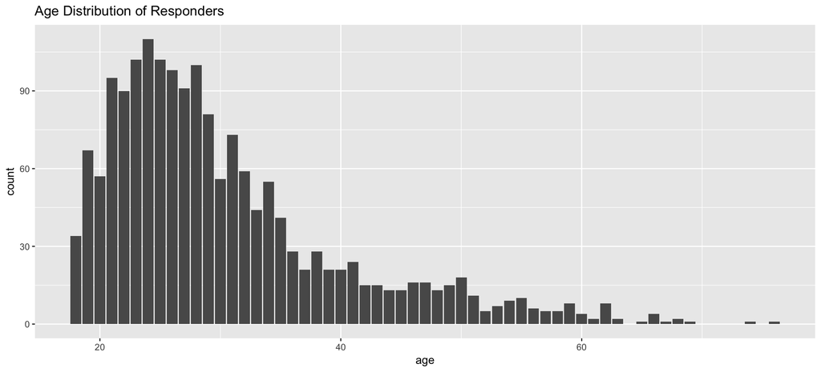

```r
radio3 %>%
  select(age) %>%
  ggplot(aes(x = age)) + geom_histogram(stat="count") +
  labs(title="Age Distribution of Responders")
```

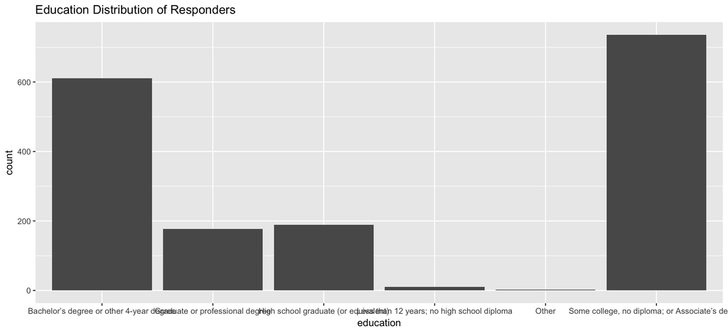

```r
radio3 %>%
  select(education) %>%
  ggplot(aes(x = education)) + geom_histogram(stat="count") +
  labs(title="Education Distribution of Responders")
```

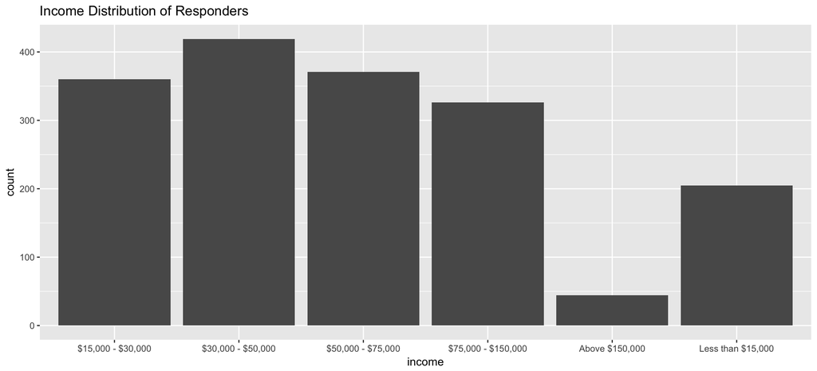

```r
radio3 %>%
  select(income) %>%
  ggplot(aes(x = income)) + geom_histogram(stat="count") +
  labs(title="Income Distribution of Responders")
```

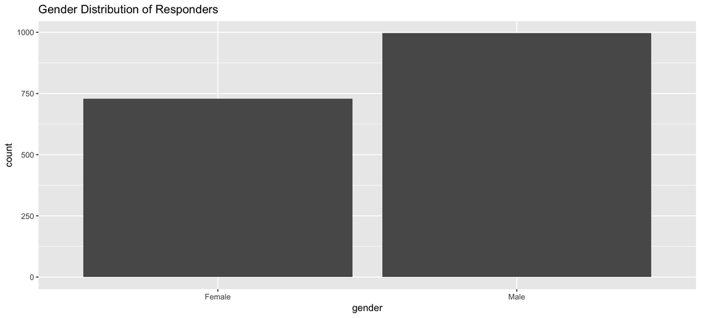

```r
radio3 %>%
  select(gender) %>%
  ggplot(aes(x = gender)) + geom_histogram(stat="count") +
  labs(title="Gender Distribution of Responders")
```

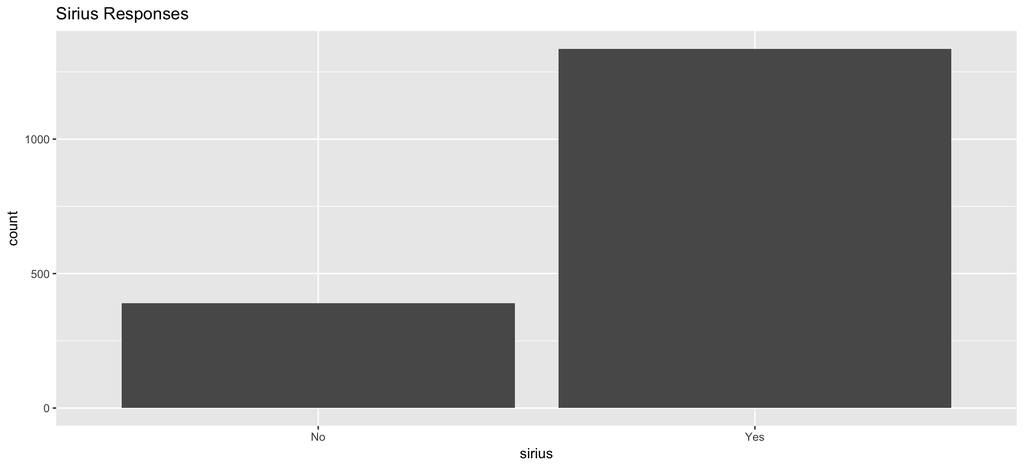

```r
radio3 %>%
  select(sirius) %>%
  ggplot(aes(x = sirius)) + geom_histogram(stat="count") +
  labs(title="Sirius Responses")
```

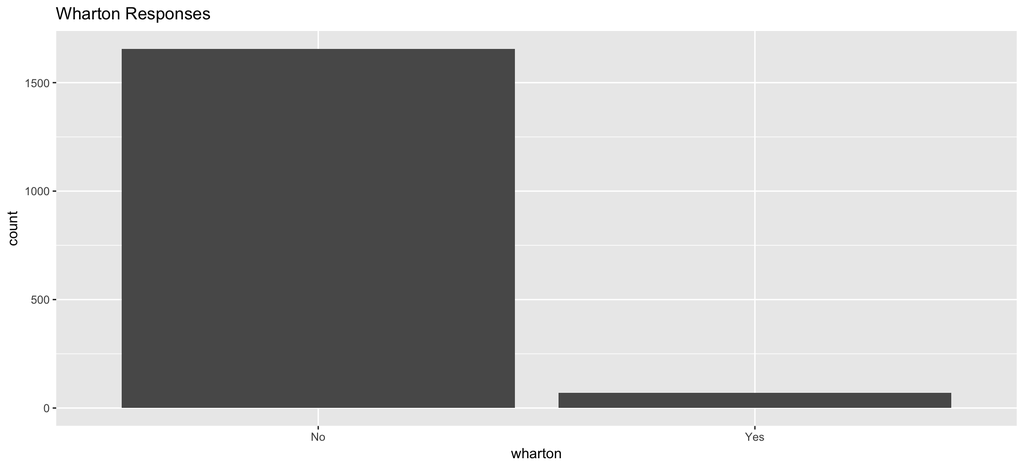

```r
radio3 %>%
  select(wharton) %>%
  ggplot(aes(x = wharton)) + geom_histogram(stat="count") +
  labs(title="Wharton Responses")
```

Write a brief report to summarize all the variables collected. Include both summary statistics (including sample size) and graphical displays such as histograms or bar charts where appropriate. Comment on what you have found from this sample. (For example - it’s very interesting to think about why would one work for a job that pays only 10cents/each survey? Who are those survey workers? The answer may be interesting even if it may not directly relate to our goal.)

- 78% of the respondents earn < $75,000 per year
- Those earning less than $15,000 might be home-makers, retired professionals for extra income
- 59% are in the age range of 18-29 years. They might be young professionals who use a lot of internet and want to earn a little extra income in their spare time

### Q1.4 Sample property questions

1. Does this sample appear to be a random sample from the general population of the USA?

No, it is not a random sample because: * age distribution in the sample does not match the general population of USA * gender distribution does not match either because male-female ratio is approximately 1:1 in USA

Sources: 1. US Census Bureau 2. http://www.kff.org/other/state-indicator/distribution-by-age/ 3. http://www.kff.org/other/state-indicator/distribution-by-gender/

2. Does this sample appear to be a random sample from the MTURK population?

Yes, it a reasonably random sample of the MTURK population: * age, gender and income are similar in both populations

Sources: http://www.pewinternet.org/2016/07/11/research-in-the-crowdsourcing-age-a-case-study/pi_2016-07-11_mechanical-turk_4-01/

### Q1.5

4. Give a final estimate of the Wharton audience size in January 2014. Assume that the sample is a random sample of the MTURK population, and that the proportion of Wharton listeners vs. Sirius listeners remains the same in the general population as it is in the MTURK population. Briefly summarize your findings and how you came to that conclusion.

```r
numberOfSiriusMTurkListeners <- radio %>%
  filter(sirius == "Yes")

numberOfWhartonMTurkListeners <- radio %>%
  filter(sirius == "Yes" & wharton == "Yes")

ratioOfWhartonToSiriusListeners <- nrow(numberOfWhartonMTurkListeners)/nrow(numberOfSiriusMTurkListeners)

estimatedSiriusPopulation <- 51600000
estimatedWhartonListeners <- (ratioOfWhartonToSiriusListeners * estimatedSiriusPopulation)

estimatedWhartonListeners
```

```
## [1] 2587725
```

# Simple Regression

## Question 2

This exercise is designed to help you understand the linear model and see everything through simulations.

Presume that $x$ and $y$ are linearly related with a normal error, such that $y = 1 + 1.2x + \epsilon$. The standard deviation of the error is $\sigma = 2$.

Note: we can create a sample input vector ($n = 40$) for $x$ with the following code:

```r
x <- seq(0, 1, length = 40)
```

### Q2.1

Create a corresponding output vector for $y$ according to the equation given above. Then, create a scatterplot with $\left(x, y\right)$ pairs. Base R plotting is acceptable, but if you can, attempt to use `ggplot2` to create the plot.

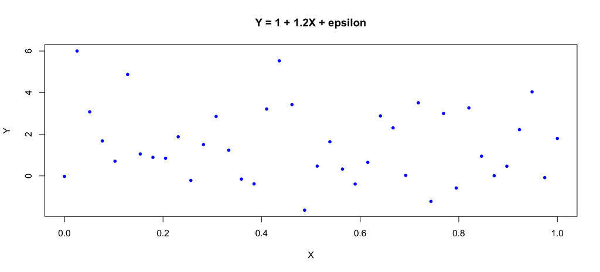

```r
set.seed(22)
x <- seq(0, 1, length = 40)
y <- 1 + 1.2*x + rnorm(40, sd=2)

plot(x, y,
       pch  = 16,
       cex  = 0.8,
       col  = "blue",
       xlab = "X",
       ylab = "Y",
       main = "Y = 1 + 1.2X + epsilon")
```

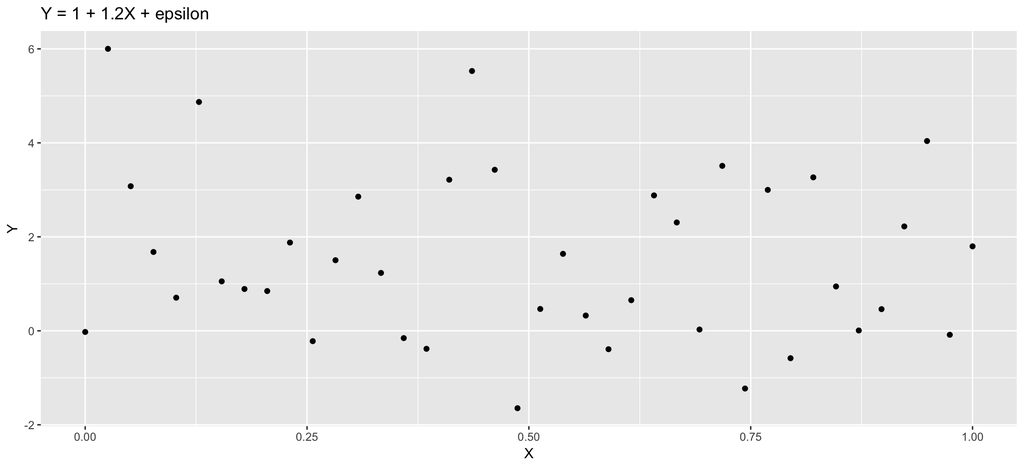

```r
ggplot(data.frame(x, y), aes(x, y)) + geom_point() + labs(title="Y = 1 + 1.2X + epsilon", x='X', y='Y')
```

### Q2.2

Find the LS estimates of $\beta_0$ and $\beta_1$, using the `lm()` function.

```r
lse <- lm(y ~ x)
lse_summary <- summary(lse)$coefficients
lse_summary
```

```
##               Estimate Std. Error    t value    Pr(>|t|)
## (Intercept)  1.9589697  0.5641073  3.4726897 0.001301699
## x           -0.8388126  0.9708589 -0.8639902 0.393014371
```

### Q2.3

Overlay the LS estimates onto a copy of the scatterplot you made above.

```r
par("bg")
```

```
## [1] "white"
```

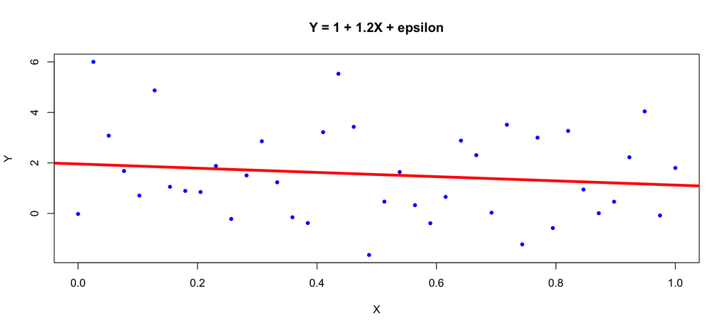

```r
plot(x, y,
       pch  = 16,
       cex  = 0.8,
       col  = "blue",
       xlab = "X",
       ylab = "Y",
       main = "Y = 1 + 1.2X + epsilon")
abline(lse, col="red", lwd=4)
```

### Q2.4

What is the 95% confidence interval for $\beta_1$? Does this confidence interval capture the true $\beta_1$?

```r
lse_summary
```

```
##               Estimate Std. Error    t value    Pr(>|t|)
## (Intercept)  1.9589697  0.5641073  3.4726897 0.001301699
## x           -0.8388126  0.9708589 -0.8639902 0.393014371
```

```r
xStandardError = lse_summary[2,2]
beta1 = lse_summary[2,1]
tstar <- qt(0.975, 38) # we need 2.5% at each side so 97.5, df = n-1
upperci = beta1 + tstar * xStandardError
lowerci = beta1 - tstar * xStandardError

results <- cbind(xStandardError, beta1, upperci, lowerci)
results
```

```
##      xStandardError      beta1  upperci   lowerci
## [1,]      0.9708589 -0.8388126 1.126589 -2.804214
```

What is your RSE for this linear model fit? Is it close to $\sigma = 2$?

```r
summary(lse)
```

```
##
## Call:
## lm(formula = y ~ x)
##
## Residuals:
##     Min      1Q  Median      3Q     Max
## -3.1972 -1.2221 -0.3764  1.2360  4.0637
##
## Coefficients:
##             Estimate Std. Error t value Pr(>|t|)
## (Intercept)   1.9590     0.5641   3.473   0.0013 **
## x            -0.8388     0.9709  -0.864   0.3930
## ---
## Signif. codes:  0 '***' 0.001 '**' 0.01 '*' 0.05 '.' 0.1 ' ' 1
##
## Residual standard error: 1.817 on 38 degrees of freedom
## Multiple R-squared:  0.01927,    Adjusted R-squared:  -0.006543
## F-statistic: 0.7465 on 1 and 38 DF,  p-value: 0.393
```

RSE is 1.817 which is close to $\sigma = 2$

### Q2.6

This part aims to help understand the notion of sampling statistics, confidence intervals. Let’s concentrate on estimating the slope only.

Generate 100 samples of size $n = 40$, and estimate the slope coefficient from each sample. We include some sample code below, which should aim you in setting up the simulation. Note: this code is written clearly but suboptimally; see the appendix for a more R-like way to do this simulation.

```r
x <- seq(0, 1, length = 40)
n_sim <- 100
b1 <- numeric(n_sim)   # nsim many LS estimates of beta1 (=1.2)
upper_ci <- numeric(n_sim)  # lower bound
lower_ci <- numeric(n_sim)  # upper bound
t_star <- qt(0.975, 38)

# Carry out the simulation
for (i in 1:n_sim){
  y <- 1 + 1.2 * x + rnorm(40, sd = 2)
  lse <- lm(y ~ x)
  lse_out <- summary(lse)$coefficients
  se <- lse_out[2, 2]
  b1[i] <- lse_out[2, 1]
  upper_ci[i] <- b1[i] + t_star * se
  lower_ci[i] <- b1[i] - t_star * se
}
results <- cbind(se, b1, upper_ci, lower_ci)
rm(se, b1, upper_ci, lower_ci, x, n_sim, b1, t_star, lse, lse_out)
```

1. Summarize the LS estimates of $\beta_1$ (in the above, `sim_results$b1`). Does the sampling distribution agree with the theory?

```r
summary(results)
```

```
##        se              b1             upper_ci        lower_ci
##  Min.   :1.094   Min.   :-0.8461   Min.   :1.182   Min.   :-3.14534
##  1st Qu.:1.094   1st Qu.: 0.5684   1st Qu.:2.598   1st Qu.:-1.60029
##  Median :1.094   Median : 1.2665   Median :3.366   Median :-0.85467
##  Mean   :1.094   Mean   : 1.2962   Mean   :3.442   Mean   :-0.84952
##  3rd Qu.:1.094   3rd Qu.: 2.0586   3rd Qu.:4.283   3rd Qu.:-0.05894
##  Max.   :1.094   Max.   : 4.6228   Max.   :6.376   Max.   : 2.87006
```

From the summary, we can say that about 95% of the simulation estimates fall within the 95% CI we constructed.

2. How many times do your 95% confidence intervals cover the true $\beta_1$? Display your confidence intervals graphically.

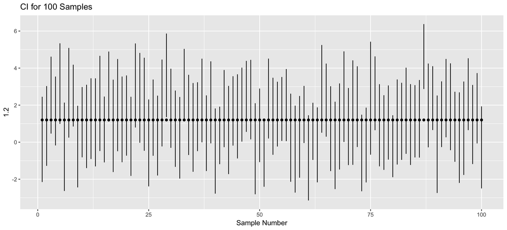

```r
res <- data.frame(results)
res$Index <- seq_len(nrow(res))

l <- length(which((res['upper_ci']) >= 1.2 &  (res['lower_ci']) <= 1.2))

ggplot(res, aes(Index, 1.2)) + geom_point() + geom_segment(data=res,
               aes(x=Index,y=upper_ci,yend=lower_ci,xend=Index)) + labs(title='CI for 100 Samples', x='Sample Number')
```

The true $\beta_1$ is covered 96 times.

# Multiple Regression

## Question 3:

You can access the necessary data with the following code:

```r
# check if you have ISLR package, if not, install it
if(!requireNamespace('ISLR')) install.packages('ISLR')
auto_data <- ISLR::Auto
```

Get familiar with this dataset first. You can use `?ISLR::Auto` to view a description of the dataset.

### Q3.1

Explore the data, with particular focus on pairwise plots and summary statistics. Briefly summarize your findings and any peculiarities in the data.

```r
summary(auto_data)
```

```
##       mpg          cylinders      displacement     horsepower
##  Min.   : 9.00   Min.   :3.000   Min.   : 68.0   Min.   : 46.0
##  1st Qu.:17.00   1st Qu.:4.000   1st Qu.:105.0   1st Qu.: 75.0
##  Median :22.75   Median :4.000   Median :151.0   Median : 93.5
##  Mean   :23.45   Mean   :5.472   Mean   :194.4   Mean   :104.5
##  3rd Qu.:29.00   3rd Qu.:8.000   3rd Qu.:275.8   3rd Qu.:126.0
##  Max.   :46.60   Max.   :8.000   Max.   :455.0   Max.   :230.0
##
##      weight      acceleration        year           origin
##  Min.   :1613   Min.   : 8.00   Min.   :70.00   Min.   :1.000
##  1st Qu.:2225   1st Qu.:13.78   1st Qu.:73.00   1st Qu.:1.000
##  Median :2804   Median :15.50   Median :76.00   Median :1.000
##  Mean   :2978   Mean   :15.54   Mean   :75.98   Mean   :1.577
##  3rd Qu.:3615   3rd Qu.:17.02   3rd Qu.:79.00   3rd Qu.:2.000
##  Max.   :5140   Max.   :24.80   Max.   :82.00   Max.   :3.000
##
##                  name
##  amc matador       :  5
##  ford pinto        :  5
##  toyota corolla    :  5
##  amc gremlin       :  4
##  amc hornet        :  4
##  chevrolet chevette:  4
##  (Other)           :365
```

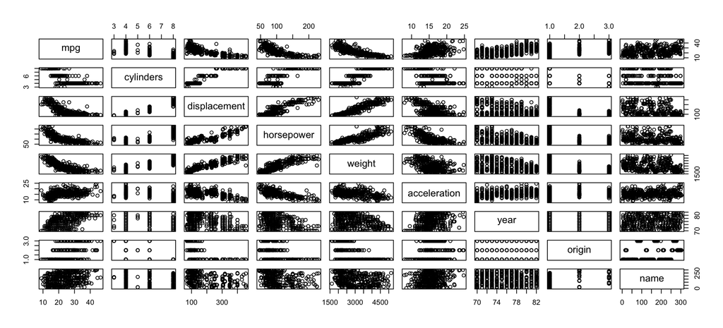

```r
pairs(auto_data)
```

Summary: Cars from 1970 - 1982 with a wide range of characteristics

We find that there might be a linear relationship between: * displacement vs horsepower * displacement vs weight * displacement vs cylinders * horsepower vs weight * horsepower vs acceleration * mpg vs horsepower * mpg vs weight * mpg vs displacement

### Q3.2

What effect does time have on MPG?

1. Start with a simple regression of mpg vs. year and report R’s `summary` output. Is year a significant variable at the .05 level? State what effect year has on mpg, if any, according to this model.

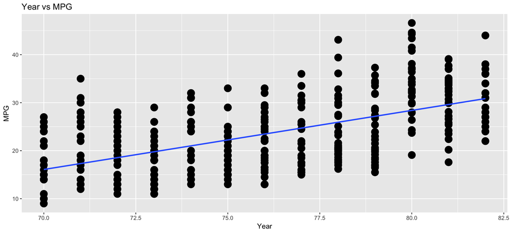

```r
ggplot(auto_data, aes(year,mpg)) + geom_point(size=5) + labs(title="Year vs MPG", x = "Year", y = "MPG") + geom_smooth(method="lm", se=FALSE)
```

```r
auto_year_lse = lm(auto_data$mpg ~ auto_data$year)
summary(auto_year_lse)
```

```
##
## Call:
## lm(formula = auto_data$mpg ~ auto_data$year)
##
## Residuals:
##      Min       1Q   Median       3Q      Max
## -12.0212  -5.4411  -0.4412   4.9739  18.2088
##
## Coefficients:
##                 Estimate Std. Error t value Pr(>|t|)
## (Intercept)    -70.01167    6.64516  -10.54   <2e-16 ***
## auto_data$year   1.23004    0.08736   14.08   <2e-16 ***
## ---
## Signif. codes:  0 '***' 0.001 '**' 0.01 '*' 0.05 '.' 0.1 ' ' 1
##
## Residual standard error: 6.363 on 390 degrees of freedom
## Multiple R-squared:  0.337,  Adjusted R-squared:  0.3353
## F-statistic: 198.3 on 1 and 390 DF,  p-value: < 2.2e-16
```

Yes, year is a significant variable at the .05 level since our P value < 0.0001 According to our model, for every increase in year, we get a 1.23004 increase in mpg.

2. Add horsepower on top of the variable year. Is year still a significant variable at the .05 level? Give a precise interpretation of the year effect found here.

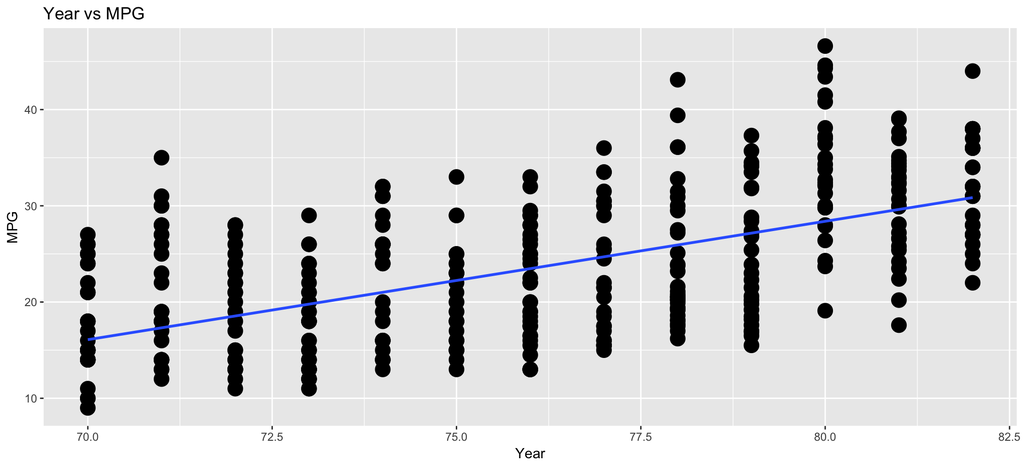

```r
ggplot(auto_data, aes(year,mpg)) + geom_point(size=5) + labs(title="Year vs MPG", x = "Year", y = "MPG") + geom_smooth(method="lm", se=FALSE)
```

```r
auto_yearhp_lse = lm(auto_data$mpg ~ auto_data$year + auto_data$horsepower)
summary(auto_yearhp_lse)
```

```
##
## Call:
## lm(formula = auto_data$mpg ~ auto_data$year + auto_data$horsepower)
##
## Residuals:
##      Min       1Q   Median       3Q      Max
## -12.0768  -3.0783  -0.4308   2.5884  15.3153
##
## Coefficients:
##                        Estimate Std. Error t value Pr(>|t|)
## (Intercept)          -12.739166   5.349027  -2.382   0.0177 *
## auto_data$year         0.657268   0.066262   9.919   <2e-16 ***
## auto_data$horsepower  -0.131654   0.006341 -20.761   <2e-16 ***
## ---
## Signif. codes:  0 '***' 0.001 '**' 0.01 '*' 0.05 '.' 0.1 ' ' 1
##
## Residual standard error: 4.388 on 389 degrees of freedom
## Multiple R-squared:  0.6855, Adjusted R-squared:  0.6839
## F-statistic: 423.9 on 2 and 389 DF,  p-value: < 2.2e-16
```

Yes, year is still significant at the 0.5 level since P < 0.0001

According to our model, for every increase in year, holding horsepower constant, we can expect a 0.657268 increase in mpg.

3. The two 95% CI’s for the coefficient of year differ among i) and ii). How would you explain the difference to a non-statistician?

```r
t_star_auto <- qt(0.975, 389)

lse_year_out <- summary(auto_year_lse)$coefficients
se <- lse_year_out[2, 2]
b1 <- lse_year_out[2, 1]
upper_ci1 <- b1 + t_star_auto * se
lower_ci2 <- b1 - t_star_auto * se

year_CI <- cbind(se, b1, upper_ci1, lower_ci2)

lse_yearhp_out <- summary(auto_yearhp_lse)$coefficients
se2 <- lse_yearhp_out[2, 2]
b12 <- lse_yearhp_out[2, 1]
upper_ci3 <- b12 + t_star_auto * se2
lower_ci4 <- b12 - t_star_auto * se2

yearhp_CI <- cbind(se2, b12, upper_ci3, lower_ci4)

year_CI
```

```
##              se       b1 upper_ci1 lower_ci2
## [1,] 0.08735748 1.230035  1.401787  1.058284
```

```r
yearhp_CI
```

```
##             se2       b12 upper_ci3 lower_ci4
## [1,] 0.06626182 0.6572678 0.7875439 0.5269917
```

The two CI’s are different because these are derived from two different models. One uses only year while the other uses year+horsepower. These two models yield different beta estimates and hence, different confidence intervals.

4. Do a model with interaction by fitting `lm(mpg ~ year * horsepower)`. Is the interaction effect significant at .05 level? Explain the year effect (if any).

```r
auto_yeartimeshp_lse = lm(auto_data$mpg ~ auto_data$year * auto_data$horsepower)
summary(auto_yeartimeshp_lse)
```

```
##
## Call:
## lm(formula = auto_data$mpg ~ auto_data$year * auto_data$horsepower)
##
## Residuals:
##      Min       1Q   Median       3Q      Max
## -12.3492  -2.4509  -0.4557   2.4056  14.4437
##
## Coefficients:
##                                       Estimate Std. Error t value Pr(>|t|)
## (Intercept)                         -1.266e+02  1.212e+01 -10.449   <2e-16
## auto_data$year                       2.192e+00  1.613e-01  13.585   <2e-16
## auto_data$horsepower                 1.046e+00  1.154e-01   9.063   <2e-16
## auto_data$year:auto_data$horsepower -1.596e-02  1.562e-03 -10.217   <2e-16
##
## (Intercept)                         ***
## auto_data$year                      ***
## auto_data$horsepower                ***
## auto_data$year:auto_data$horsepower ***
## ---
## Signif. codes:  0 '***' 0.001 '**' 0.01 '*' 0.05 '.' 0.1 ' ' 1
##
## Residual standard error: 3.901 on 388 degrees of freedom
## Multiple R-squared:  0.7522, Adjusted R-squared:  0.7503
## F-statistic: 392.5 on 3 and 388 DF,  p-value: < 2.2e-16
```

### Q3.3

Remember that the same variable can play different roles! Take a quick look at the variable `cylinders`, try to use this variable in the following analyses wisely. We all agree that larger number of cylinder will lower mpg. However, we can interpret `cylinders` as either a continuous (numeric) variable or a categorical variable.

1. Fit a model, that treats `cylinders` as a continuous/numeric variable: `lm(mpg ~ horsepower + cylinders, ISLR::Auto)`. Is `cylinders` significant at the 0.01 level? What effect does `cylinders` play in this model?

```r
auto_cylinders_lse = lm(auto_data$mpg ~ auto_data$horsepower + auto_data$cylinders)
summary(auto_cylinders_lse)
```

```
##
## Call:
## lm(formula = auto_data$mpg ~ auto_data$horsepower + auto_data$cylinders)
##
## Residuals:
##      Min       1Q   Median       3Q      Max
## -11.4378  -3.2422  -0.3721   2.3532  16.9289
##
## Coefficients:
##                      Estimate Std. Error t value Pr(>|t|)
## (Intercept)          42.94842    0.77880  55.147  < 2e-16 ***
## auto_data$horsepower -0.08612    0.01119  -7.693 1.19e-13 ***
## auto_data$cylinders  -1.91982    0.25261  -7.600 2.24e-13 ***
## ---
## Signif. codes:  0 '***' 0.001 '**' 0.01 '*' 0.05 '.' 0.1 ' ' 1
##
## Residual standard error: 4.584 on 389 degrees of freedom
## Multiple R-squared:  0.6569, Adjusted R-squared:  0.6551
## F-statistic: 372.4 on 2 and 389 DF,  p-value: < 2.2e-16
```

Yes, cylinders is significant at the 0.01 level. For every increase in cylinders, holding horsepower constant, we have a decrease in mpg of 1.91982

2. Fit a model that treats `cylinders` as a categorical/factor variable: `lm(mpg ~ horsepower + as.factor(cylinders), ISLR::Auto)`. Is `cylinders` significant at the .01 level? What is the effect of `cylinders` in this model? Use `anova(fit1, fit2)` and `Anova(fit2`)`to help gauge the effect. Explain the difference between`anova()`and`Anova`.

```r
auto_cat_cylinders_lse = lm(auto_data$mpg ~ auto_data$horsepower + as.factor(auto_data$cylinders))
summary(auto_cat_cylinders_lse)
```

```
##
## Call:
## lm(formula = auto_data$mpg ~ auto_data$horsepower + as.factor(auto_data$cylinders))
##
## Residuals:
##     Min      1Q  Median      3Q     Max
## -9.5917 -2.7067 -0.6102  1.9001 16.3258
##
## Coefficients:
##                                 Estimate Std. Error t value Pr(>|t|)
## (Intercept)                     30.77614    2.41283  12.755  < 2e-16 ***
## auto_data$horsepower            -0.10303    0.01133  -9.095  < 2e-16 ***
## as.factor(auto_data$cylinders)4  6.57344    2.16921   3.030  0.00261 **
## as.factor(auto_data$cylinders)5  5.07367    3.26661   1.553  0.12120
## as.factor(auto_data$cylinders)6 -0.34406    2.18580  -0.157  0.87501
## as.factor(auto_data$cylinders)8  0.49738    2.27639   0.218  0.82716
## ---
## Signif. codes:  0 '***' 0.001 '**' 0.01 '*' 0.05 '.' 0.1 ' ' 1
##
## Residual standard error: 4.27 on 386 degrees of freedom
## Multiple R-squared:  0.7046, Adjusted R-squared:  0.7008
## F-statistic: 184.1 on 5 and 386 DF,  p-value: < 2.2e-16
```

```r
anova(auto_cylinders_lse, auto_cat_cylinders_lse)
```

```
## Analysis of Variance Table
##
## Model 1: auto_data$mpg ~ auto_data$horsepower + auto_data$cylinders
## Model 2: auto_data$mpg ~ auto_data$horsepower + as.factor(auto_data$cylinders)
##   Res.Df    RSS Df Sum of Sq      F    Pr(>F)
## 1    389 8172.5
## 2    386 7036.7  3    1135.8 20.769 1.705e-12 ***
## ---
## Signif. codes:  0 '***' 0.001 '**' 0.01 '*' 0.05 '.' 0.1 ' ' 1
```

```r
library('car')
Anova(auto_cat_cylinders_lse)
```

```
## Anova Table (Type II tests)
##
## Response: auto_data$mpg
##                                Sum Sq  Df F value    Pr(>F)
## auto_data$horsepower           1507.8   1  82.712 < 2.2e-16 ***
## as.factor(auto_data$cylinders) 2349.2   4  32.217 < 2.2e-16 ***
## Residuals                      7036.7 386
## ---
## Signif. codes:  0 '***' 0.001 '**' 0.01 '*' 0.05 '.' 0.1 ' ' 1
```

It is better to use Anova(fit2) because in anova(fit1, fit2), fit1 is not a subset of fit2 and cannot be compared since the equations are different - cylinders is numeric in fit1 and categorical in fit2.

Yes, cylinders is significant at the 0.01 level.

3. What are the fundamental differences between treating `cylinders` as a numeric and or a factor models?

The difference between treating cylinder as numeric and as a factor is that it creates completely diffrent models. When treated as a factor, you get many variables and estimates while numeric variable only has one estimate. In the categorical model, the estimates are derived from the first variable in the factor that is treated as the intercept. While considering cylinders as a numeric variable, when the number of cylinders double, the corresponding increase in mpg also doubles. But this is not true when cylinders is considered as a factor. When the number of cylinders double, the corresponding increase in mpg would not double.

### Q3.4

Final modelling question: we want to explore the effects of each feature as best as possible. You may explore interactions, feature transformations, higher order terms, or other strategies within reason. The model(s) should be as parsimonious (simple) as possible unless the gain in accuracy is significant from your point of view.

1. Describe the final model. Include diagnostic plots with particular focus on the model residuals and diagnoses.
2. Summarize the effects found.
3. Predict the mpg of a car that is: built in 1983, in US, red, 180 inches long, 8 cylinders, 350 displacement, 260 as horsepower and weighs 4000 pounds. Give a 95% CI.

```r
model1 <- lm(mpg ~ weight + year + origin, data=auto_data)
summary(model1)
```

```
##
## Call:
## lm(formula = mpg ~ weight + year + origin, data = auto_data)
##
## Residuals:
##     Min      1Q  Median      3Q     Max
## -9.9440 -2.0948 -0.0389  1.7255 13.2722
##
## Coefficients:
##               Estimate Std. Error t value Pr(>|t|)
## (Intercept) -1.805e+01  4.001e+00  -4.510 8.60e-06 ***
## weight      -5.994e-03  2.541e-04 -23.588  < 2e-16 ***
## year         7.571e-01  4.832e-02  15.668  < 2e-16 ***
## origin       1.150e+00  2.591e-01   4.439 1.18e-05 ***
## ---
## Signif. codes:  0 '***' 0.001 '**' 0.01 '*' 0.05 '.' 0.1 ' ' 1
##
## Residual standard error: 3.348 on 388 degrees of freedom
## Multiple R-squared:  0.8175, Adjusted R-squared:  0.816
## F-statistic: 579.2 on 3 and 388 DF,  p-value: < 2.2e-16
```

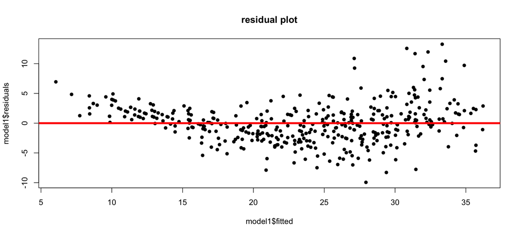

```r
new_data <- data.frame(weight=4000, year= 83, origin=1)
prediction <- predict(model1, newdata=new_data, interval='confidence')

plot(model1$fitted, model1$residuals,
     pch  = 16,
     main = "residual plot")
abline(h=0, lwd=4, col="red")
```

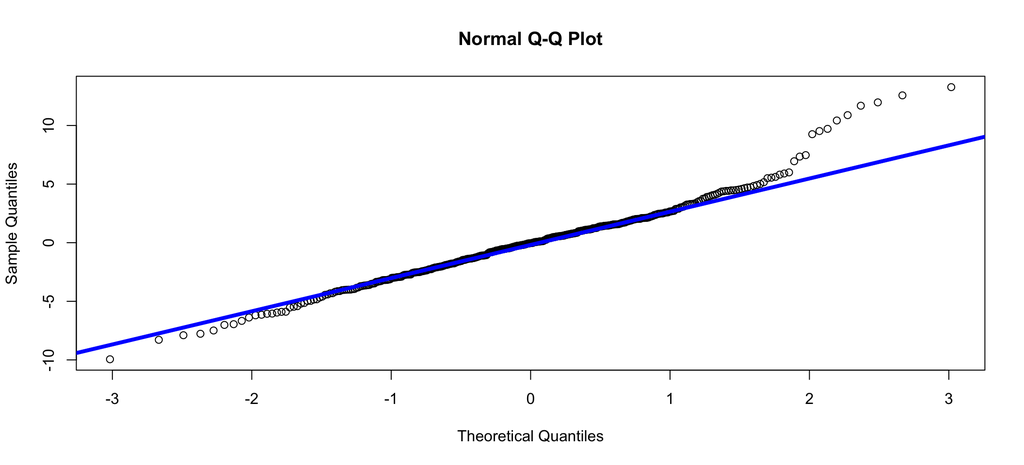

```r
qqnorm(model1$residuals)
  qqline(model1$residuals, lwd=4, col="blue")
```

The final model with the least number of terms which gives the highest Adjusted R-squared is the one which includes weight, year and origin. * With every increase of one 1 lbs of weight, keeping year and origin constant, the mpg decreases by 0.00599. * With every increase of one year, keeping weight and origin constant, the mpg increases by 0.757.

The predicted mpg of a car that is: built in 1983, in US, red, 180 inches long, 8 cylinders, 350 displacement, 260 as horsepower and weighs 4000 pounds, is 21.9695362miles per gallon.

The 95% CI is 21.0173562 and 22.9217163miles per gallon.

## Appendix

This is code that is roughly equivalent to what we provide above in Question 2 (simulations).

```r
simulate_lm <- function(n) {
  # note: `n` is an input but not used (don't worry about this hack)
  x <- seq(0, 1, length = 40)
  y <- 1 + 1.2 * x + rnorm(40, sd = 2)
  t_star <- qt(0.975, 38)
  lse <- lm(y ~ x)
  lse_out <- summary(lse)$coefficients
  se <- lse_out[2, 2]
  b1 <- lse_out[2, 1]
  upper_CI = b1 + t_star * se
  lower_CI = b1 - t_star * se
  return(data.frame(se, b1, upper_CI, lower_CI))
}

# this step runs the simulation 100 times,
# then matrix transposes the result so rows are observations
sim_results <- data.frame(t(sapply(X = 1:100, FUN = simulate_lm)))
```